# AD - Multivariant Analysis

Pau Mateo, Arnau Biosca, Pau Fernández

2024-05-12

```r
data_euroleague <- read.csv2("C:/Users/pauma/OneDrive/Escritorio/UNI/2n/AD/anàlisi_multivariant/Homeworks/Homework1/euroleague_22_23.csv",
                             stringsAsFactors=FALSE,  na.strings="")
```

1. Exploratory data analysis.

Let’s start with an exploratory analysis of the data that we are going to use in this workshop.

```r
head(data_euroleague, n=10L)
```

```
##    No      TEAM             PLAYER POSITION GP GS      Min  PTS X2P. X3P.  FT.
## 1   1 AS MONACO         ELIE OKOBO    Guard 41  6 26:00:00 12.6 52.9 33.5 83.7
## 2   2 AS MONACO         JOHN BROWN  Forward 41 38 22:24:00  5.4 48.9 37.5 68.2
## 3   3 AS MONACO       CHIMA MONEKE  Forward 16  1 12:37:00  3.9 51.3  0.0 88.5
## 4   4 AS MONACO        JORDAN LOYD    Guard 34 29 25:20:00 12.3 50.3 37.1 89.9
## 5   5 AS MONACO  JARON BLOSSOMGAME  Forward 38 17 17:21:00  5.1 58.5 25.0 55.6
## 6   6 AS MONACO     YOAN MAKOUNDOU   Center  8  0  9:33:00  4.4 50.0 20.0 80.0
## 7   7 AS MONACO       ALPHA DIALLO  Forward 41 15 24:45:00 10.5 53.3 29.8 75.0
## 8   8 AS MONACO     ADRIEN MOERMAN     <NA> 16  2 14:35:00  2.9 26.1 22.7 50.0
## 9   9 AS MONACO DONATAS MOTIEJUNAS   Center 41 37 17:47:00  8.5 63.5 25.0 55.8
## 10 10 AS MONACO    YAKUBA OUATTARA    Guard 35 15 11:10:00  3.7 60.4 35.4 50.0
##     OR  DR  TR AST STL  TO BLK BLKA  FC  FD  PIR
## 1  0.3 1.9 2.1 3.6 1.0 2.1 0.2  0.3 2.5 3.0 12.0
## 2  2.1 1.4 3.5 0.8 1.1 0.7 0.2  0.1 2.6 1.7  6.5
## 3  1.1 2.0 3.1 0.5 0.2 0.8 0.2  0.2 1.9 1.1  4.6
## 4  0.3 2.1 2.4 2.7 1.3 1.2 0.1  0.2 2.6 3.8 13.4
## 5  0.9 1.8 2.7 0.2 0.3 0.3 0.2  0.1 1.9 1.3  4.4
## 6  1.6 1.1 2.8 0.4 0.2 0.8 0.5  0.6 0.9 0.6  4.2
## 7  1.5 2.7 4.2 2.0 1.3 1.3 0.3  0.3 2.9 2.5 11.1
## 8  0.8 1.9 2.8 0.7 0.4 0.8 0.0  0.1 1.1 0.8  2.1
## 9  1.3 2.4 3.7 0.8 0.3 0.9 0.1  0.2 1.7 3.0 10.0
## 10 0.3 0.7 1.0 0.3 0.4 0.1 0.0  0.1 1.2 0.2  2.4
```

```r
summary(data_euroleague)
```

```
##        No           TEAM              PLAYER            POSITION
##  Min.   : 1.0   Length:59          Length:59          Length:59
##  1st Qu.:15.5   Class :character   Class :character   Class :character
##  Median :30.0   Mode  :character   Mode  :character   Mode  :character
##  Mean   :30.0
##  3rd Qu.:44.5
##  Max.   :59.0
##        GP             GS            Min                 PTS
##  Min.   : 1.0   Min.   : 0.00   Length:59          Min.   : 0.000
##  1st Qu.:24.5   1st Qu.: 1.00   Class :character   1st Qu.: 3.850
##  Median :35.0   Median : 8.00   Mode  :character   Median : 6.100
##  Mean   :29.9   Mean   :13.73                      Mean   : 6.631
##  3rd Qu.:39.0   3rd Qu.:24.50                      3rd Qu.: 8.850
##  Max.   :41.0   Max.   :41.00                      Max.   :17.600
##       X2P.             X3P.             FT.               OR
##  Min.   :  0.00   Min.   :  0.00   Min.   :  0.00   Min.   :0.0000
##  1st Qu.: 47.40   1st Qu.: 25.00   1st Qu.: 66.70   1st Qu.:0.3000
##  Median : 53.70   Median : 34.90   Median : 77.10   Median :0.6000
##  Mean   : 54.61   Mean   : 30.24   Mean   : 71.52   Mean   :0.7186
##  3rd Qu.: 63.45   3rd Qu.: 39.75   3rd Qu.: 85.35   3rd Qu.:1.0000
##  Max.   :100.00   Max.   :100.00   Max.   :100.00   Max.   :2.6000
##        DR              TR             AST             STL
##  Min.   :0.000   Min.   :0.000   Min.   :0.000   Min.   :0.000
##  1st Qu.:1.050   1st Qu.:1.300   1st Qu.:0.500   1st Qu.:0.300
##  Median :1.800   Median :2.400   Median :1.000   Median :0.500
##  Mean   :1.825   Mean   :2.547   Mean   :1.468   Mean   :0.622
##  3rd Qu.:2.500   3rd Qu.:3.400   3rd Qu.:1.900   3rd Qu.:0.750
##  Max.   :5.200   Max.   :6.900   Max.   :6.600   Max.   :6.000
##        TO              BLK              BLKA              FC
##  Min.   :0.0000   Min.   :0.0000   Min.   :0.0000   Min.   :0.000
##  1st Qu.:0.6000   1st Qu.:0.0000   1st Qu.:0.1000   1st Qu.:1.200
##  Median :0.9000   Median :0.1000   Median :0.2000   Median :1.700
##  Mean   :0.9593   Mean   :0.2119   Mean   :0.1695   Mean   :1.688
##  3rd Qu.:1.2500   3rd Qu.:0.2000   3rd Qu.:0.2000   3rd Qu.:2.200
##  Max.   :2.2000   Max.   :2.2000   Max.   :0.6000   Max.   :3.000
##        FD            PIR
##  Min.   :0.00   Min.   :-1.000
##  1st Qu.:0.80   1st Qu.: 3.250
##  Median :1.50   Median : 6.400
##  Mean   :1.68   Mean   : 7.373
##  3rd Qu.:2.60   3rd Qu.:11.250
##  Max.   :5.10   Max.   :21.500
```

1. Discard the variable “No” from the data set.

As we can see, the variable ‘No’ simply indicates the row number, so we do not care about this variable and can eliminate it from our data.

```r
data <- data_euroleague[ -c(1) ]
head(data, n = 8L)
```

```
##        TEAM            PLAYER POSITION GP GS      Min  PTS X2P. X3P.  FT.  OR
## 1 AS MONACO        ELIE OKOBO    Guard 41  6 26:00:00 12.6 52.9 33.5 83.7 0.3
## 2 AS MONACO        JOHN BROWN  Forward 41 38 22:24:00  5.4 48.9 37.5 68.2 2.1
## 3 AS MONACO      CHIMA MONEKE  Forward 16  1 12:37:00  3.9 51.3  0.0 88.5 1.1
## 4 AS MONACO       JORDAN LOYD    Guard 34 29 25:20:00 12.3 50.3 37.1 89.9 0.3
## 5 AS MONACO JARON BLOSSOMGAME  Forward 38 17 17:21:00  5.1 58.5 25.0 55.6 0.9
## 6 AS MONACO    YOAN MAKOUNDOU   Center  8  0  9:33:00  4.4 50.0 20.0 80.0 1.6
## 7 AS MONACO      ALPHA DIALLO  Forward 41 15 24:45:00 10.5 53.3 29.8 75.0 1.5
## 8 AS MONACO    ADRIEN MOERMAN     <NA> 16  2 14:35:00  2.9 26.1 22.7 50.0 0.8
##    DR  TR AST STL  TO BLK BLKA  FC  FD  PIR
## 1 1.9 2.1 3.6 1.0 2.1 0.2  0.3 2.5 3.0 12.0
## 2 1.4 3.5 0.8 1.1 0.7 0.2  0.1 2.6 1.7  6.5
## 3 2.0 3.1 0.5 0.2 0.8 0.2  0.2 1.9 1.1  4.6
## 4 2.1 2.4 2.7 1.3 1.2 0.1  0.2 2.6 3.8 13.4
## 5 1.8 2.7 0.2 0.3 0.3 0.2  0.1 1.9 1.3  4.4
## 6 1.1 2.8 0.4 0.2 0.8 0.5  0.6 0.9 0.6  4.2
## 7 2.7 4.2 2.0 1.3 1.3 0.3  0.3 2.9 2.5 11.1
## 8 1.9 2.8 0.7 0.4 0.8 0.0  0.1 1.1 0.8  2.1
```

2. Split variable “Min” using strsplit() function. Give the name aux to the output. The first element of each row will show the minutes that the player played in total.

```r
if (is.factor(data$Min)) {
    data$Min <- as.character(data$Min)
}

if (is.numeric(data$Min)) {
    data$Min <- as.character(data$Min)
}
aux <- strsplit(data$Min, split=":")
```

3. Add a numerical variable to the data set named “Min 2” which shows how many minutes each player played in the game.

```r
Min2 <- matrix(unlist(aux), ncol = 3, byrow = TRUE)[,1]
data$Min2 <- as.numeric(Min2)
head(data)
```

```
##        TEAM            PLAYER POSITION GP GS      Min  PTS X2P. X3P.  FT.  OR
## 1 AS MONACO        ELIE OKOBO    Guard 41  6 26:00:00 12.6 52.9 33.5 83.7 0.3
## 2 AS MONACO        JOHN BROWN  Forward 41 38 22:24:00  5.4 48.9 37.5 68.2 2.1
## 3 AS MONACO      CHIMA MONEKE  Forward 16  1 12:37:00  3.9 51.3  0.0 88.5 1.1
## 4 AS MONACO       JORDAN LOYD    Guard 34 29 25:20:00 12.3 50.3 37.1 89.9 0.3
## 5 AS MONACO JARON BLOSSOMGAME  Forward 38 17 17:21:00  5.1 58.5 25.0 55.6 0.9
## 6 AS MONACO    YOAN MAKOUNDOU   Center  8  0  9:33:00  4.4 50.0 20.0 80.0 1.6
##    DR  TR AST STL  TO BLK BLKA  FC  FD  PIR Min2
## 1 1.9 2.1 3.6 1.0 2.1 0.2  0.3 2.5 3.0 12.0   26
## 2 1.4 3.5 0.8 1.1 0.7 0.2  0.1 2.6 1.7  6.5   22
## 3 2.0 3.1 0.5 0.2 0.8 0.2  0.2 1.9 1.1  4.6   12
## 4 2.1 2.4 2.7 1.3 1.2 0.1  0.2 2.6 3.8 13.4   25
## 5 1.8 2.7 0.2 0.3 0.3 0.2  0.1 1.9 1.3  4.4   17
## 6 1.1 2.8 0.4 0.2 0.8 0.5  0.6 0.9 0.6  4.2    9
```

```r
print(data)
```

```
##            TEAM                 PLAYER POSITION GP GS      Min  PTS  X2P.
## 1     AS MONACO             ELIE OKOBO    Guard 41  6 26:00:00 12.6  52.9
## 2     AS MONACO             JOHN BROWN  Forward 41 38 22:24:00  5.4  48.9
## 3     AS MONACO           CHIMA MONEKE  Forward 16  1 12:37:00  3.9  51.3
## 4     AS MONACO            JORDAN LOYD    Guard 34 29 25:20:00 12.3  50.3
## 5     AS MONACO      JARON BLOSSOMGAME  Forward 38 17 17:21:00  5.1  58.5
## 6     AS MONACO         YOAN MAKOUNDOU   Center  8  0  9:33:00  4.4  50.0
## 7     AS MONACO           ALPHA DIALLO  Forward 41 15 24:45:00 10.5  53.3
## 8     AS MONACO         ADRIEN MOERMAN     <NA> 16  2 14:35:00  2.9  26.1
## 9     AS MONACO     DONATAS MOTIEJUNAS   Center 41 37 17:47:00  8.5  63.5
## 10    AS MONACO        YAKUBA OUATTARA    Guard 35 15 11:10:00  3.7  60.4
## 11    AS MONACO        MATTHEW STRAZEL    Guard 25  3  8:08:00  2.5  56.0
## 12    AS MONACO             DONTA HALL   Center 41  4 18:38:00  7.5  72.9
## 13    AS MONACO            MIKE JAMES     Guard 38 38 30:21:00 15.9  45.9
## 14  REAL MADRID    NIGEL WILLIAMS-GOSS    Guard 26 23 15:47:00  7.4  58.3
```

[output cut: 105 more lines]

The new variable ‘Min’ can also be eliminated becasue we only care about the total minutes played per player. This information is already saved in the new variable ‘Min2’

```r
data <- data[ -c(6) ]
```

4. Check the structure of the data and assign correct type to each variable considering whether it is a categorical or a numerical variable.

The variables ‘TEAM,PLAYER,POSITION’ are categorical, so we have to convert them to factors. The other variables are numerical so there is no trouble.

```r
data$TEAM     <- factor(data$TEAM)
data$PLAYER   <- factor(data$PLAYER)
data$POSITION <- factor(data$POSITION)
```

2. Application of PCA.
1. Apply PCA on all the scaled numerical variables in the data set by using PCA() function in FactoMineR package. Treat the categorical variables and the variable “PIR” as supplementary variables using arguments quali.sup and quanti.sup correctly.

```r
#install.packages("FactorMineR")
#install.packages("factoextra")
library(FactoMineR)
library(factoextra)
```

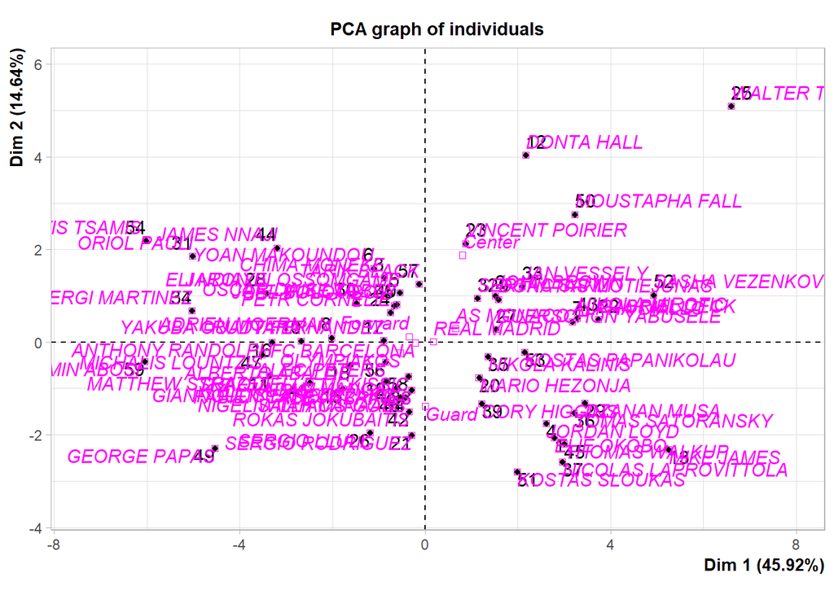

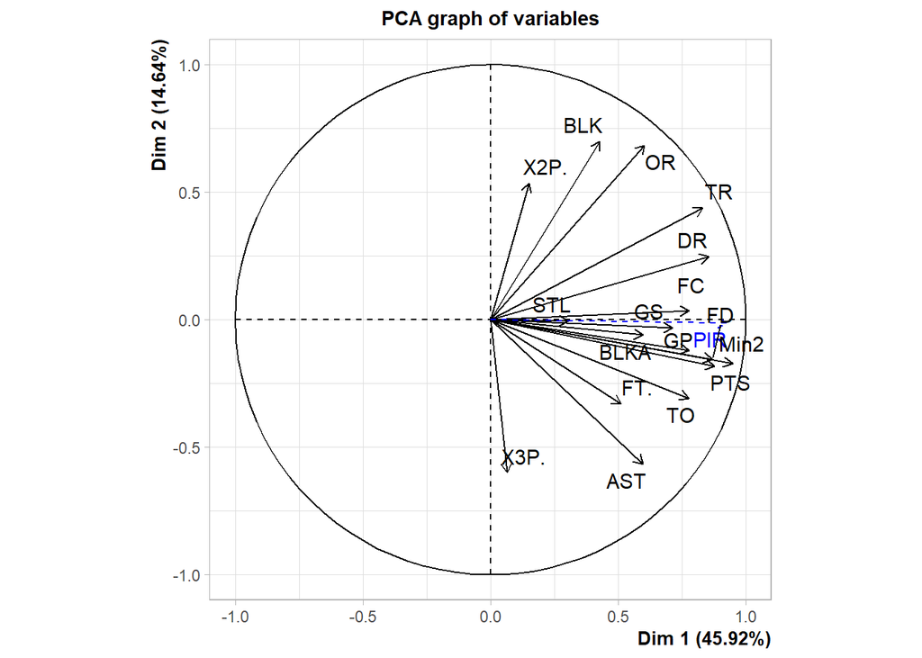

```r
data.pca <- PCA(data, quali.sup = c(1,2,3), quanti.sup = 20)
```

Here we can notice that the second dimension is separating the players between exterior players and interior players. If we look at the stats, we can see that the ones that go up, represent the stats that are normally associated with centers or power forwards, such as blocks, scoring 2 points and offensive and defensive rebounds. On the oher hand, we can see that the ones that go down represent exterior players: three-pointers, free throws, assists,etc.

We have found the first dimension a little bit more difficult to interpret, but we think that this dimension separates between the attributes that contribute more for the personal stats, and the ones that contribute a lot for the whole team. The distribution between doubles and three-pointers is not really important for the whole team, and the steals dont matter that much. Nevertheless, defensive rebounds, fouls drawn and total points scored, are things that help a lot in a match for the whole team.

```
## Too few points to calculate an ellipse
```

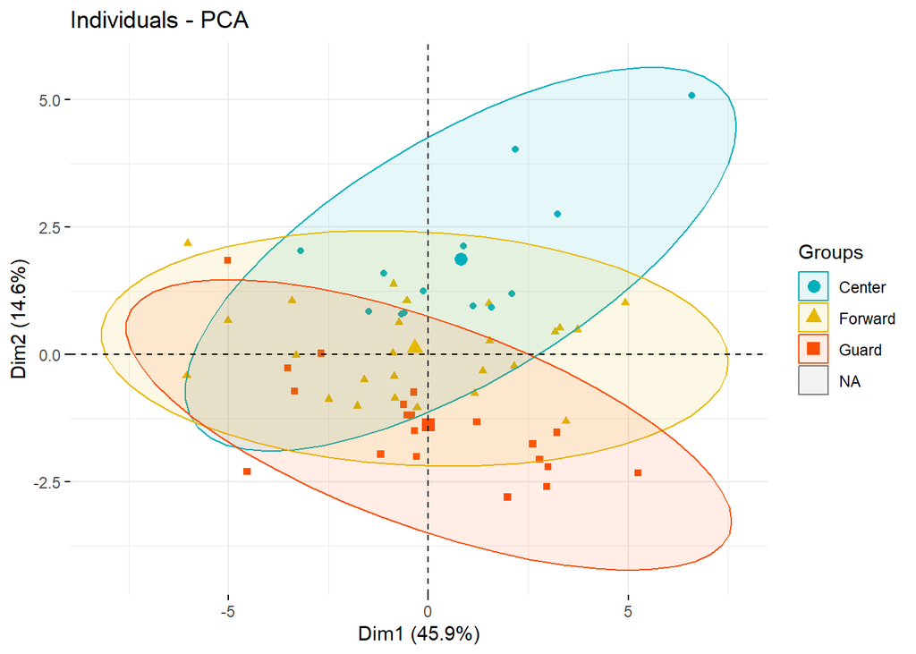

```r
fviz_pca_ind(data.pca,
             geom.ind = "point", # show points only (nbut not "text")
             col.ind = data$POSITION, # color by groups
             palette = c("#00AFBB", "#E7B800", "#FC4E07","black"),
             addEllipses = TRUE, # Concentration ellipses
             legend.title = "Groups"
             )
```

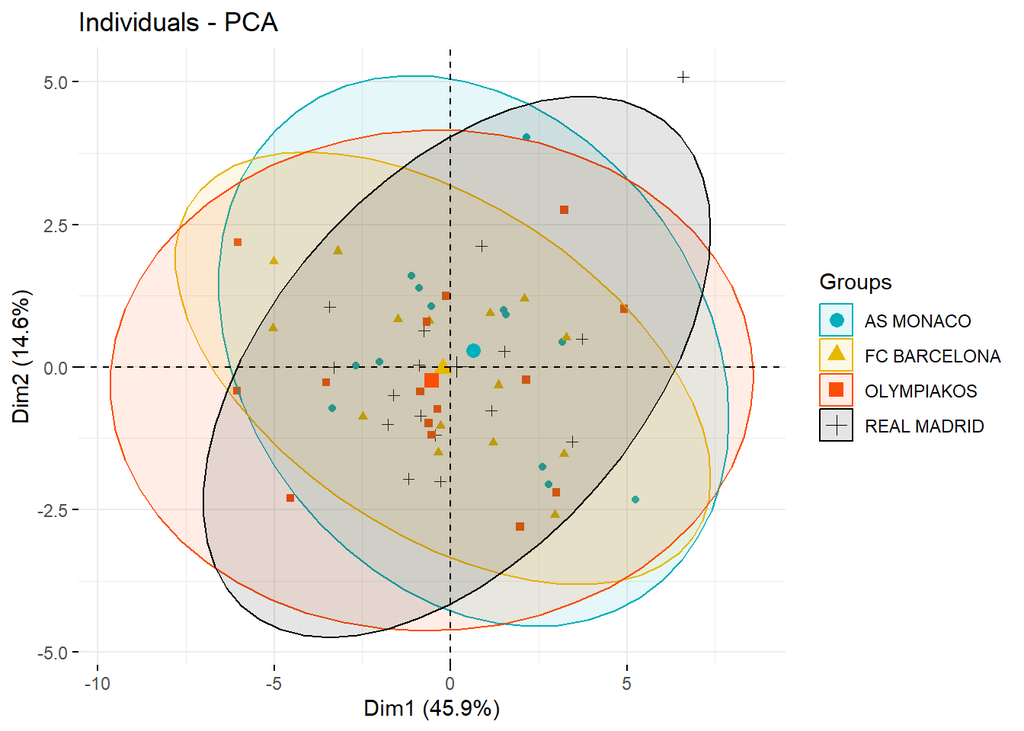

```r
fviz_pca_ind(data.pca,
             geom.ind = "point", # show points only (nbut not "text")
             col.ind = data$TEAM, # color by groups
             palette = c("#00AFBB", "#E7B800", "#FC4E07", "black"),
             addEllipses = TRUE, # Concentration ellipses
             legend.title = "Groups"
             )
```

We can see that the suplementary variable PIR is highly correlated with the first principal component. The variable PIR is a measure that gives us information about the general performance of the player, taking into account all the other stats.

With this statement, we reaffirm that the first dimension is the contribution to the whole team. As an observation, we can see that in Real Madrid, the centers contribute more to the team than the exterior players. This is probably Tavares’ fault.

2. How many components should be extracted? Decide on the number of components considering eigenvalues.

To decide how many components we have to eliminate, we have to look at the amount of variability explained by the principal components. To do so, let’s look at the PCA eigenvalues.

```r
data.pca$eig
```

```
##           eigenvalue percentage of variance cumulative percentage of variance
## comp 1  7.8068860551           45.922859148                          45.92286
## comp 2  2.4895377796           14.644339880                          60.56720
## comp 3  1.3495172073            7.938336513                          68.50554
## comp 4  1.1608795844            6.828703438                          75.33424
## comp 5  0.9015901290            5.303471347                          80.63771
## comp 6  0.7203308264            4.237240156                          84.87495
## comp 7  0.6299899556            3.705823268                          88.58077
## comp 8  0.4641877857            2.730516386                          91.31129
## comp 9  0.3986831091            2.345194759                          93.65648
## comp 10 0.3022677380            1.778045517                          95.43453
## comp 11 0.2372433883            1.395549343                          96.83008
## comp 12 0.2072484973            1.219108808                          98.04919
## comp 13 0.1399129308            0.823017240                          98.87221
## comp 14 0.0791043348            0.465319616                          99.33753
## comp 15 0.0688605140            0.405061847                          99.74259
## comp 16 0.0431877925            0.254045838                          99.99663
## comp 17 0.0005723722            0.003366895                         100.00000
```

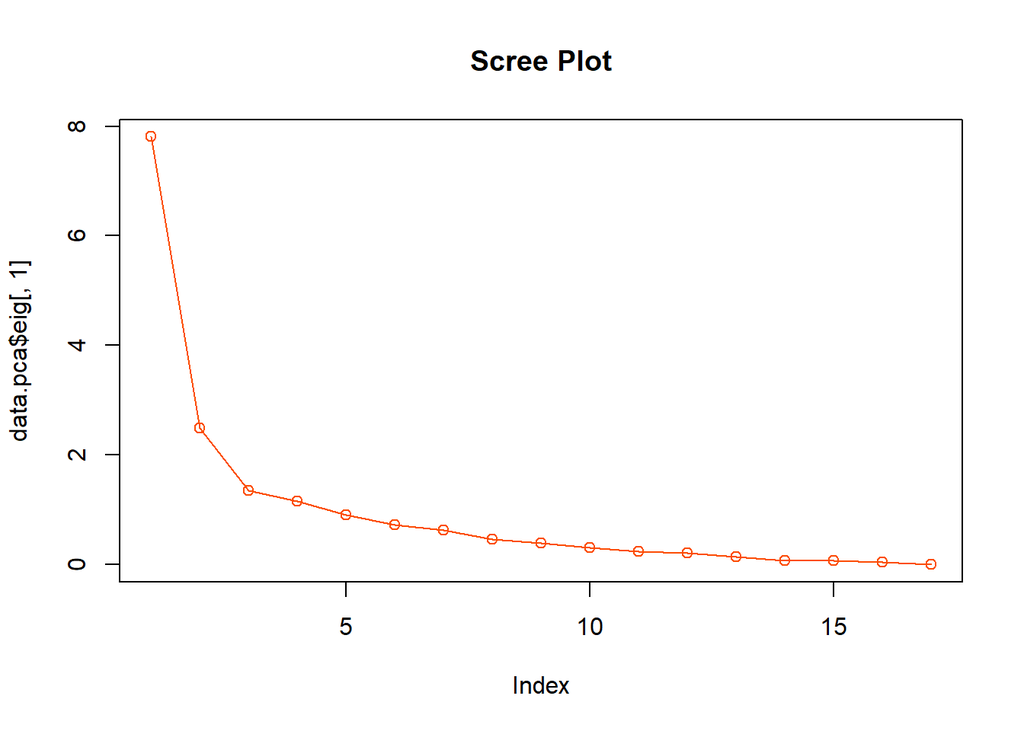

```r
plot(data.pca$eig[,1], type="o", main="Scree Plot", col="#FC4E07")
```

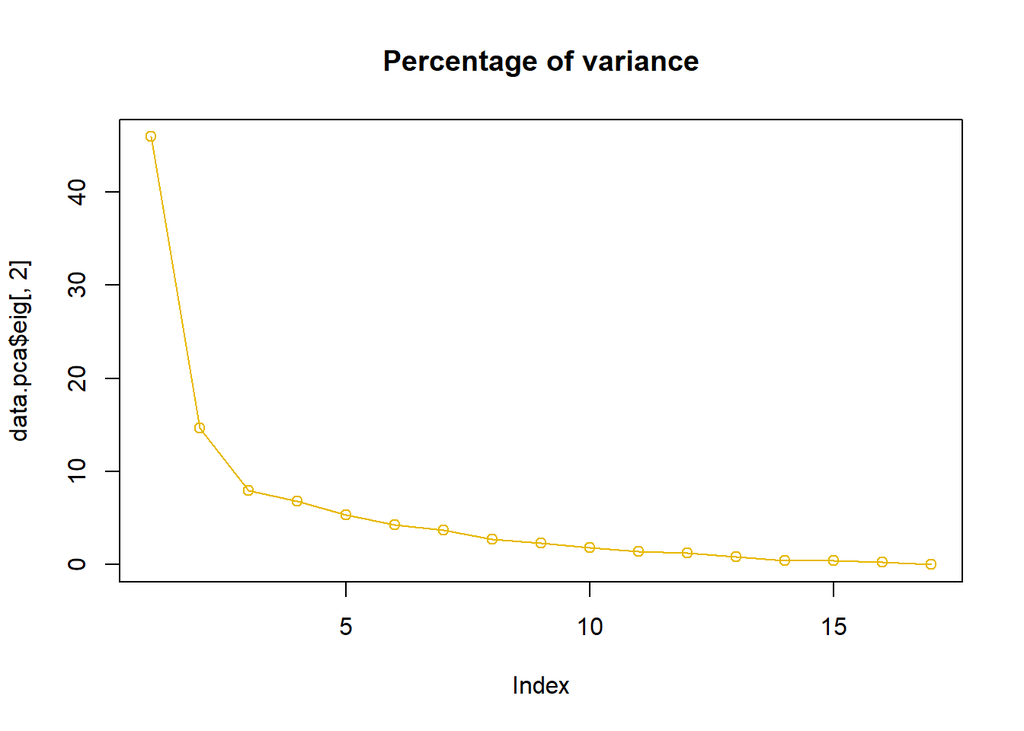

```r
plot(data.pca$eig[,2], type="o", main="Percentage of variance", col="#E7B800")
```

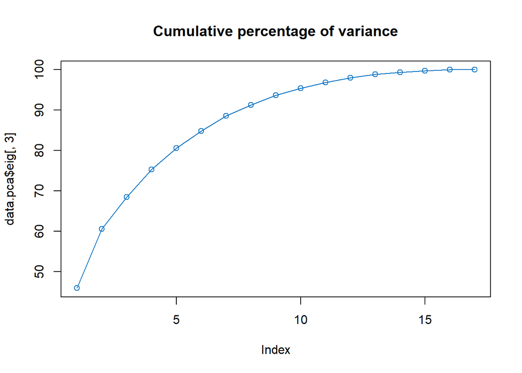

```r
plot(data.pca$eig[,3], type="o", main="Cumulative percentage of variance", col="#0073C2FF")
```

With the first component we can already explain a 45% of the total variability. The more we increase the amount of components, the more increases this percentage. We can reach an 80% of explained variability with 5 components.

3. Use plot.PCA() function to show correlations between variables and the extracted dimensions by changing “axes” according to the dimension of interest. (For the variables you should use the argument choix = “var”). Interpret the loadings/correlations of variables at each dimension.

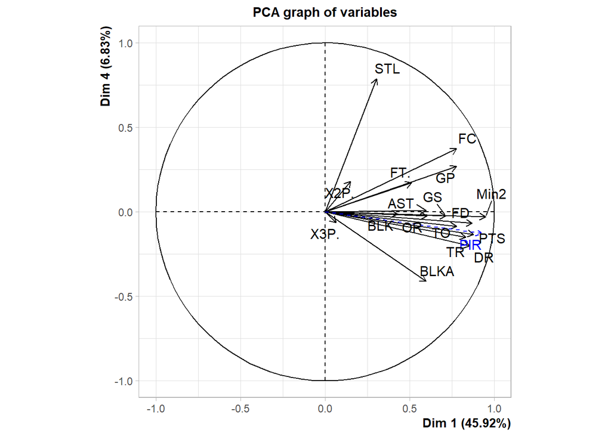

```r
plot.PCA(data.pca, choix = "var", axes = c(1, 4))
```

Now changing between the axis we can relate the different dimensions and see what these mean, looking at the arrows of the varibales. Nonetheless, as the third, fourth and fifth dimensions explain a really low percentage of the variability, it is quite more difficult to interpret what these mean.

4. Interpret variable plots. How can each dimension be named? As we said before, the first one is the contribution to the whole team, the second one is the sepparation between exterior and interior players.

We have spent a bit more time thinking about the third one and we think that this one can be related to the most and less variable stats. We can see that this dimension is separating between three-pointers and free throws (normally very consistent), and turnovers, assists and steals, that are stats that are a bit more random because they do not only depend on the skill of the player, but also on the circumstances. In the (2,3) relation, we can see that the exteriors are more consistent in free throws and three pointers, and the centers, with the rebounds, and that makes a lot of sense.

We do not know what dim4 and dim5 mean, as they explain quite less than the other dimensions.

5. Show individuals plots changing argument choix=“ind” in plot.PCA() function and interpret the important findings.

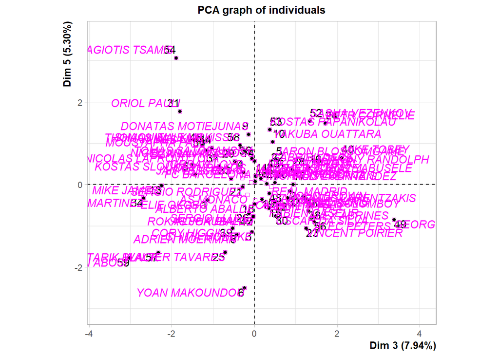

```r
plot.PCA(data.pca, choix = "ind", axes = c(3, 5))
```

Dim1 -> Here we can see the relation between good and bad players (in relation to the team contribution), because in the right zone of the plot there are highlighted players such as Laprovittola, Walter Tavares, Papanikolau, …

Dim2 -> Centers/Exteriors -> Walter,Hall,Fall / Sloukas, Papanikolau, Satoransky,…

Dim3 -> Now we can relate this dimension a little bit more accurately. It seems that this shows the accuracy of the player. If we look at the stats of George Papas, we can see that he has a 100% in three-pointers and free throws, nevertheless, he does not contribute that much to the team because he does not attempt to shoot that much, as he has aprox 3 points per game. On the other hand, we have Mike James. He is not that accurate, but as he throws a lot, he also makes a lot of points, and shooting a lot with a 45% in doubles and nearly a 30% in three-pointers is really a lot in the euroleague. For this reason, he ends contributing a lot more to the team that Papas, though having less accuracy.

Dim 4 -> We have made a discovery about this dimension. We think that this dimension can be called as ‘dirty work’. We see that this dimension values a lot the steals. The fouls commited could be interpreted as a bad thing, but in this case, they are not. This is because committing fouls means that you are defending a lot and playing ‘dirty’, as we said. This also relates to the amount of free throws that you shoot, because if you are always there, you are going to be fouled by someone very often(though this dimension requires that you make these free throws). The same applies for the other way around, as we can see with the variable ‘blocks against’. This dimension also considers ‘the amount of dirty work they are doing to you’.

We have used the tactics of looking at the furthest individuals to find out what the dimensions mean, but for the fifth one everything is very regular, so we cannot know what this dimension is explaining.

3. Application of MDS.
1. Apply metric MDS using Euclidean distance on scaled numerical variables.

```r
data_num <- data[ -c(1,2,3) ]

print(data_num)
```

```
##    GP GS  PTS  X2P.   X3P.   FT.  OR  DR  TR AST STL  TO BLK BLKA  FC  FD  PIR
## 1  41  6 12.6  52.9  33.50  83.7 0.3 1.9 2.1 3.6 1.0 2.1 0.2  0.3 2.5 3.0 12.0
## 2  41 38  5.4  48.9  37.50  68.2 2.1 1.4 3.5 0.8 1.1 0.7 0.2  0.1 2.6 1.7  6.5
## 3  16  1  3.9  51.3   0.00  88.5 1.1 2.0 3.1 0.5 0.2 0.8 0.2  0.2 1.9 1.1  4.6
## 4  34 29 12.3  50.3  37.10  89.9 0.3 2.1 2.4 2.7 1.3 1.2 0.1  0.2 2.6 3.8 13.4
## 5  38 17  5.1  58.5  25.00  55.6 0.9 1.8 2.7 0.2 0.3 0.3 0.2  0.1 1.9 1.3  4.4
## 6   8  0  4.4  50.0  20.00  80.0 1.6 1.1 2.8 0.4 0.2 0.8 0.5  0.6 0.9 0.6  4.2
## 7  41 15 10.5  53.3  29.80  75.0 1.5 2.7 4.2 2.0 1.3 1.3 0.3  0.3 2.9 2.5 11.1
## 8  16  2  2.9  26.1  22.70  50.0 0.8 1.9 2.8 0.7 0.4 0.8 0.0  0.1 1.1 0.8  2.1
## 9  41 37  8.5  63.5  25.00  55.8 1.3 2.4 3.7 0.8 0.3 0.9 0.1  0.2 1.7 3.0 10.0
## 10 35 15  3.7  60.4  35.40  50.0 0.3 0.7 1.0 0.3 0.4 0.1 0.0  0.1 1.2 0.2  2.4
## 11 25  3  2.5  56.0  32.00  66.7 0.0 0.2 0.2 0.6 0.2 0.7 0.0  0.1 1.2 0.2  2.4
## 12 41  4  7.5  72.9   0.00  71.0 2.1 3.4 5.5 0.5 0.5 0.5 0.9  0.2 2.3 2.1 12.3
## 13 38 38 15.9  45.9  27.30  78.3 0.6 3.1 3.7 4.4 1.0 2.2 0.0  0.6 1.7 5.1 16.3
## 14 26 23  7.4  58.3  38.50  77.1 0.2 1.2 1.3 1.8 0.6 1.0 0.0  0.2 1.9 1.4  6.6
```

[output cut: 105 more lines]

```r
dist_euroleague<-dist(scale(data_num), method="euclidean")
mds_euroleague<-cmdscale(dist_euroleague, eig=TRUE)
mds_euroleague
```

```
## $points
##             [,1]        [,2]
##  [1,]  2.9070998  2.03657832
##  [2,]  1.3388777 -1.00138437
##  [3,] -1.0073598 -1.37626219
##  [4,]  2.8354141  1.74136949
##  [5,] -0.7052855 -1.05619931
##  [6,] -1.2465062 -1.58073812
##  [7,]  3.2048708 -0.44519128
##  [8,] -2.2302531 -0.09629901
##  [9,]  1.6507421 -0.91833468
## [10,] -2.8352050 -0.02134695
## [11,] -3.4669320  0.72108371
## [12,]  2.3410483 -3.99905446
## [13,]  5.5116531  2.29774008
```

[output cut: 69 more lines]

2. Plot the data using the points on the first two coordinates using players positions as label.

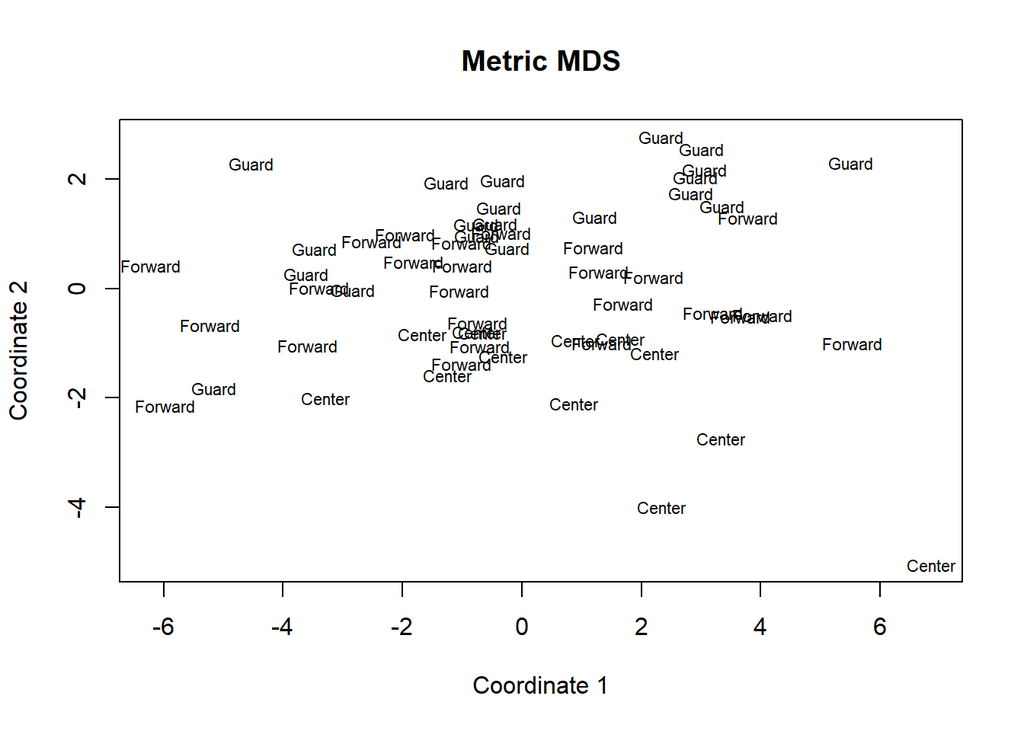

```r
x <- mds_euroleague$points[,1]
y <- mds_euroleague$points[,2]
plot(x, y, xlab="Coordinate 1", ylab="Coordinate 2",
     main="Metric MDS", type="n")
text(x, y, labels = data_euroleague$POSITION, cex=.7)
```

This is good, though to interpret the plot we also want to check the same graphic with the names of the players.

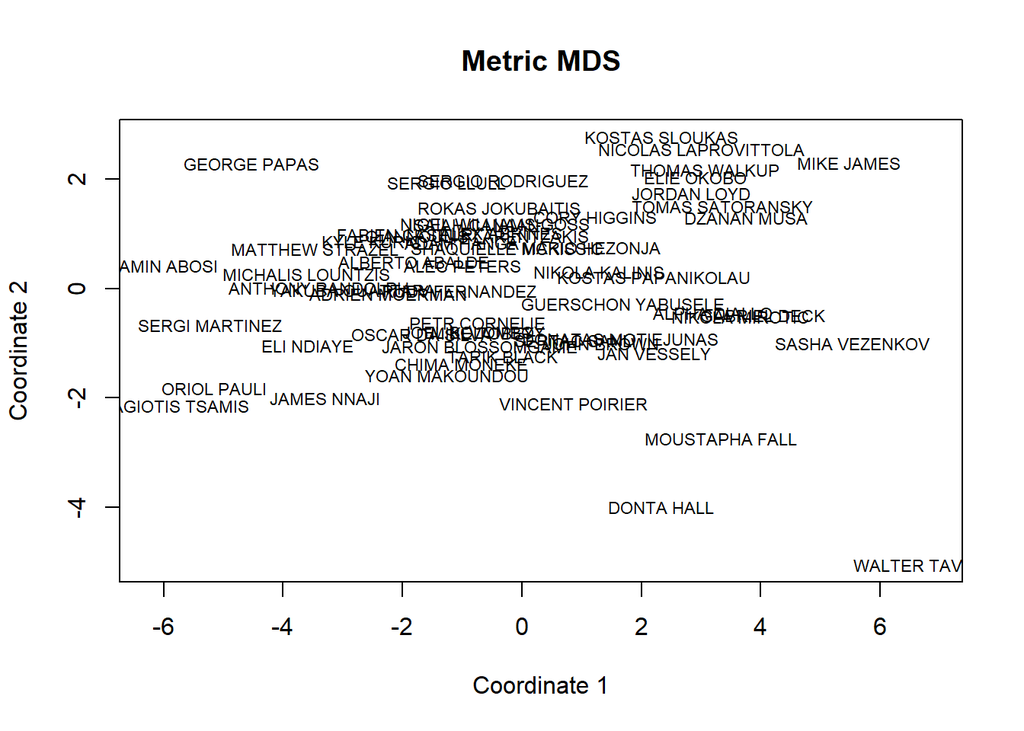

```r
x <- mds_euroleague$points[,1]
y <- mds_euroleague$points[,2]
plot(x, y, xlab="Coordinate 1", ylab="Coordinate 2",
     main="Metric MDS", type="n")
text(x, y, labels = data_euroleague$PLAYER, cex=.7)
```

3. Interpret the plot.

Now we are distinguishing between the players but preserving the distance between these players. Though we are not taking into account the not numerical attributes such as position, we see that nonetheless, this plot is distinguishing between position. This implies that the numerical values have information very valuable to determine the position of the player. This is logic, because for example, the centers are going to get more rebounds and less three-pointers.

Apart from that, the ones that are more in the right part of the plot, are better players. The distance in the plot can be extrapolated to the difference between the real behaviours of the players. We can see that Walter Tavares is practically from another planet.

4. Calculate gower distance including variable “POSITION” to the data matrix.

```r
library(cluster)
data_gower <- data[ -c(1,2) ]
dist_euroleague2 <- daisy(data_gower, metric = "gower")
```

5. Apply metric MDS on gower distance matrix.

```r
mds_euroleague2<-cmdscale(dist_euroleague2, eig=TRUE)
mds_euroleague2
```

```
## $points
##               [,1]          [,2]
##  [1,]  0.141164595  0.1292081762
##  [2,]  0.073608101 -0.0666085502
##  [3,] -0.066477518 -0.0775311601
##  [4,]  0.152956935  0.1162786055
##  [5,] -0.025929347 -0.0592179006
##  [6,] -0.103285755 -0.0995750323
##  [7,]  0.156356953 -0.0567149501
##  [8,] -0.110585191 -0.0164045778
##  [9,]  0.111934780 -0.0745634148
## [10,] -0.115091815  0.0737535808
## [11,] -0.154824860  0.0850052967
## [12,]  0.090368751 -0.1561455895
## [13,]  0.275355520  0.1598866319
```

[output cut: 69 more lines]

6. Represent individuals plot on the first two coordinates.

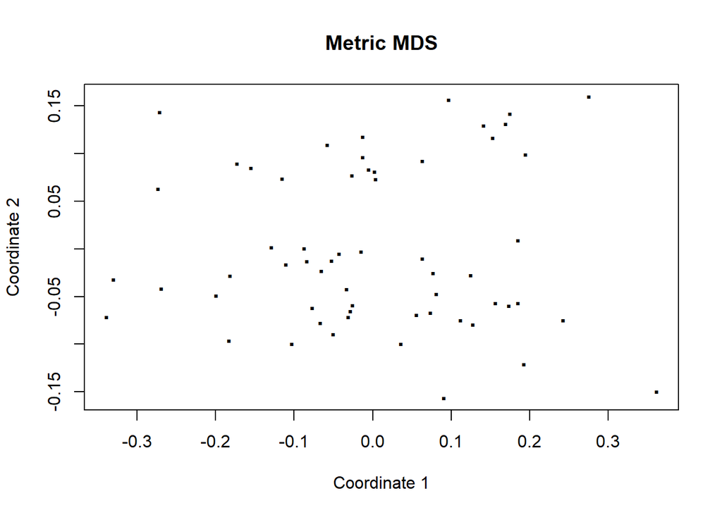

```r
z <- mds_euroleague2$points[,1]
k <- mds_euroleague2$points[,2]
plot(z, k, xlab="Coordinate 1", ylab="Coordinate 2",
     main="Metric MDS", type="n")
text(z, k, labels = '.', cex=2)
```

7. Use different categorical and numerical variables as labels so as to explain clusters that are constructed.

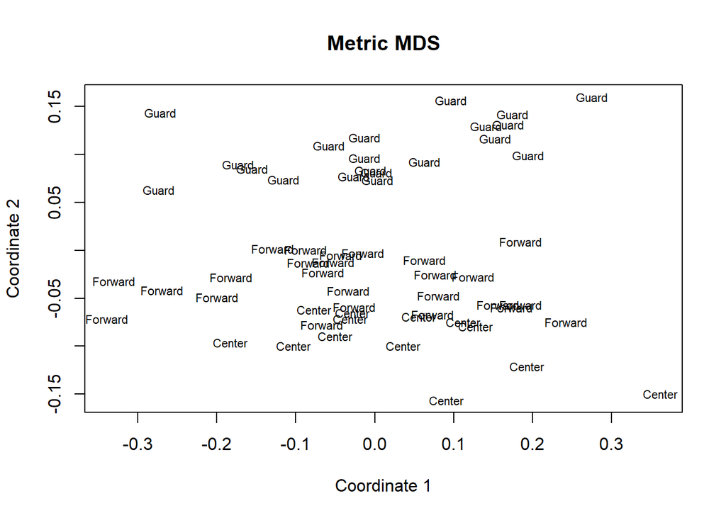

```r
z <- mds_euroleague2$points[,1]
k <- mds_euroleague2$points[,2]
plot(z, k, xlab="Coordinate 1", ylab="Coordinate 2",
     main="Metric MDS", type="n")
text(z, k, labels = data_euroleague$POSITION, cex=.7)
```

Now we see that the separation between positions in the vertical axis is more clear, because we also considered this variable with the gower distance.

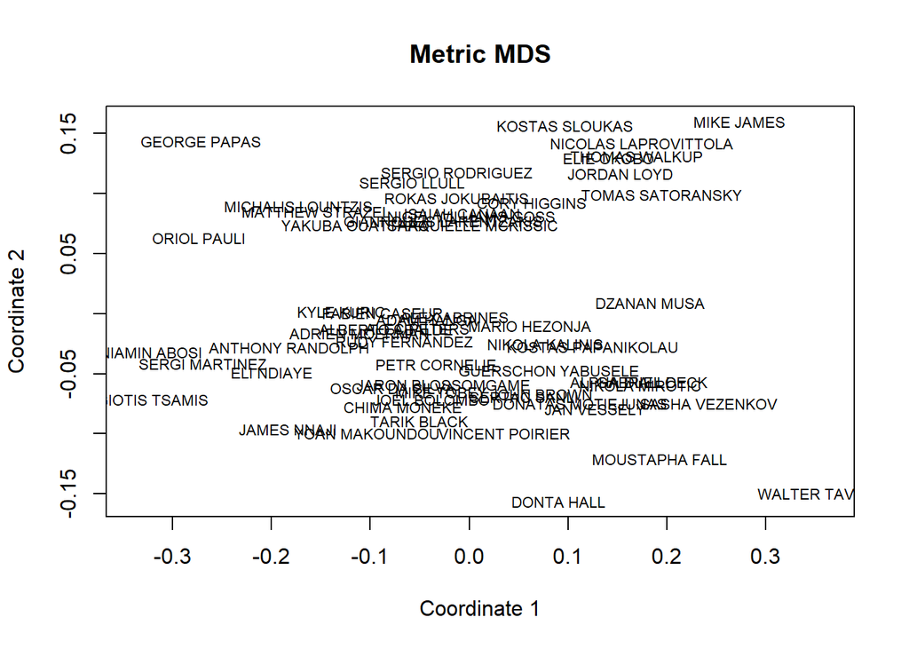

```r
z <- mds_euroleague2$points[,1]
k <- mds_euroleague2$points[,2]
plot(z, k, xlab="Coordinate 1", ylab="Coordinate 2",
     main="Metric MDS", type="n")
text(z, k, labels = data_euroleague$PLAYER, cex=.7)
```

We also see that this distance behaves quite similarly to the euclidean one, mainly because it is the same but also considering another categorical attribute. In this case we can see that the best players are still on the right, and the bad ones on the left, and we can explain the cluster in the center as the ‘normal’ behaviour of the majority of players that don’t stand out.

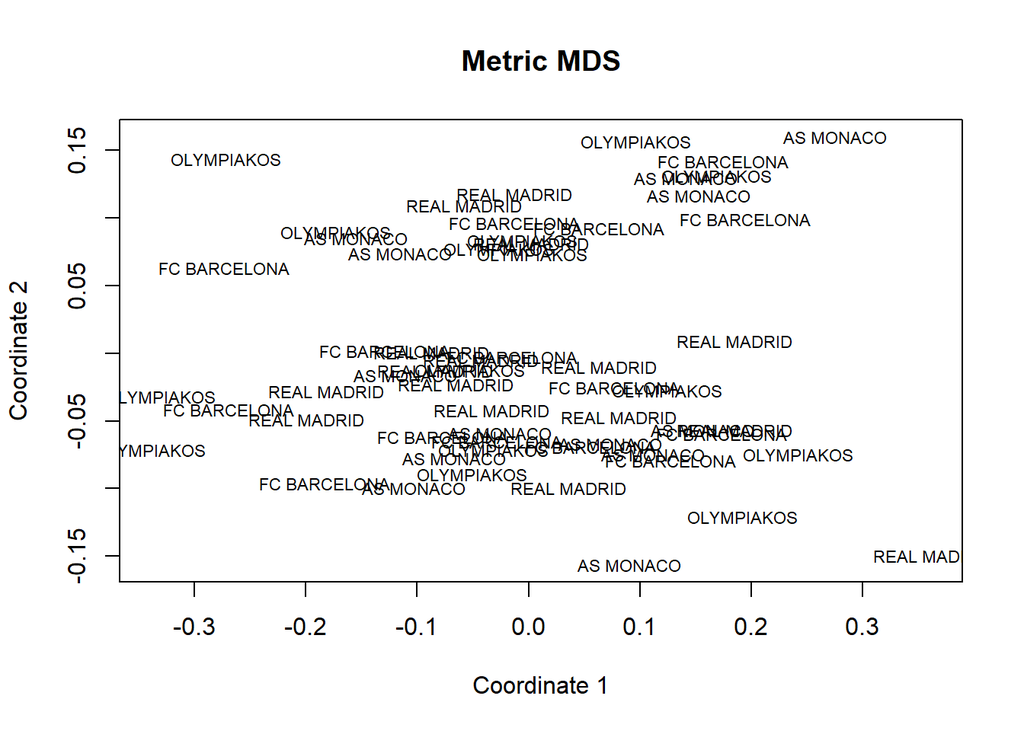

```r
z <- mds_euroleague2$points[,1]
k <- mds_euroleague2$points[,2]
plot(z, k, xlab="Coordinate 1", ylab="Coordinate 2",
     main="Metric MDS", type="n")
text(z, k, labels = data_euroleague$TEAM, cex=.7)
```

Here we can see that all the teams have bad and good players, though Olympiakos is more balanced than the others maybe. This fact can also be seen in the PCA part of the project, where we have used this command: fviz_pca_ind

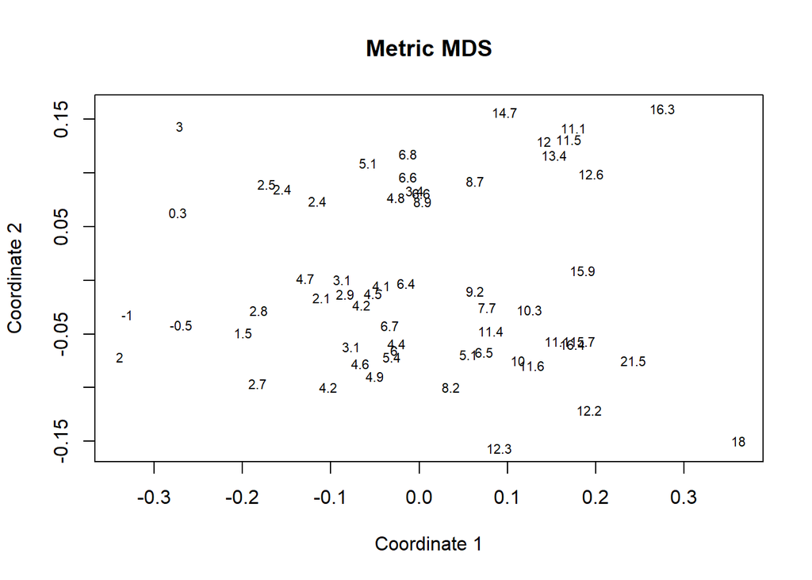

```r
z <- mds_euroleague2$points[,1]
k <- mds_euroleague2$points[,2]
plot(z, k, xlab="Coordinate 1", ylab="Coordinate 2",
     main="Metric MDS", type="n")
text(z, k, labels = data_euroleague$PIR, cex=.7)
```

This graphic does not have much to comment apart from all we said before, but it kind of reflects everything we said.

8. Which MDS do you think better group the individuals? Why?

We think that gower is better because it does not make sense not to consider the position of the player when comparing them. We cannot compare a center with a pointguard because you do not care about a center not scoring three-pointers, and you do not care about a pointguard catching 12 rebounds per game either. For this reason, we think that gower distance is better in this case.